# Swift Key project

Exploratory analysis

Bill Kelemen

February 19, 2017

## 1. Executive summary

This project will build an application to assist users when typing free form text, by predicting the next word based on previous seen words. The application will use machine learning techniques to train a model from a corpora of news, blogs and twitter data. This model will then be used to predict the next word based on the previous three words typed by the user.

This milestone report contains the analysis performed on the data available, to better understand specific characteristics by exploring different aspects like frequencies of words, word pairs, triples, etc. The exploratory analysis was performed on the English version of the corpora.

Research was done on R packages that could be used for this phase and `tidytext` was selected as the main one to use.

The next phase of the project will be to start building the predictive model. A preliminary proposal using Markov chains will be discussed as well as possible implementation requirements.

## 2. Initial processing

The corpora processed is the English version of the blogs, news and twitter files provided for the project.

The raw corpora provided for this project consists of sample text collected in three files:

| filename | size (MB) | number of lines | number of words |
| --- | --- | --- | --- |
| ../data/blogs.train.small.txt | 0 | 1000 | 42137 |
| ../data/news.train.small.txt | 0 | 1500 | 51272 |
| ../data/twitter.train.small.txt | 0 | 3000 | 38165 |

Initially the three files were loaded into R and then processed with the `tidytext` package to understand frequencies and relationships of single words, bigrams and trigrams.

The initial steps were:

1. Load raw text files
2. Clean raw text files
3. Tidy the data for unigram analysis (single words)
4. Tidy the data for bigram analysis
5. Tidy the data for trigram analysis

Additional cleaning of the data will continue in coming phases.

## 3. Exploratory analysis

### 3.1. Single words (unigram) analysis

Initial analysis was performed on single words (unigrams) to understand the frequency of words in the corpora.

[*Stop words*](https://en.wikipedia.org/wiki/Stop_words) play an important role in word frequency but in our application, we must keep them as they also must be predicted.

The following charts present this information visually, for the top 25 words, including and excluding stop words.

#### 3.1.1. Analysis including stop words

By including stop words, ‘the’ dominates all other words.

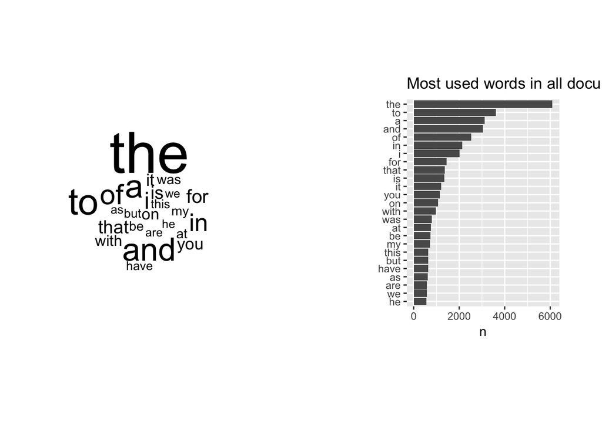

#### 3.1.2. Analysis excluding stop words

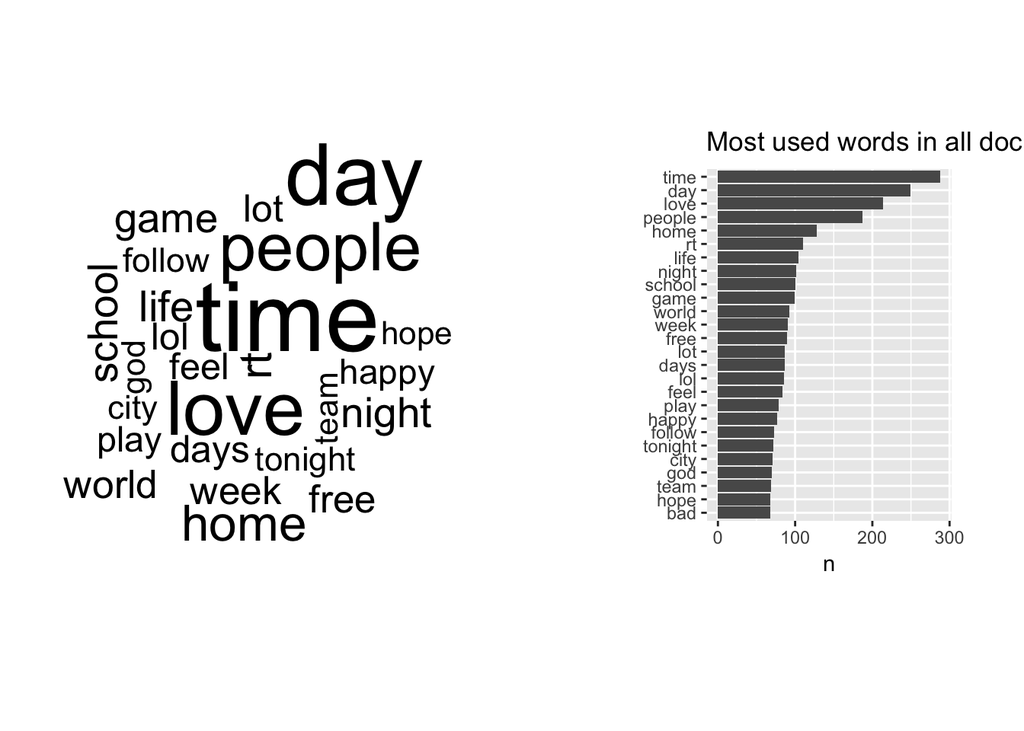

### 3.2. Bigram analysis

Following, an analysis was performed on bigrams that are sequences of 2-words.

- the total number of bigrams is 131571
- the average length of the bigrams is 9.9
- The 10 most frequent bigrams are: [‘in the’ (525), ‘of the’ (520), ‘to the’ (273), ‘for the’ (258), ‘to be’ (243), ‘on the’ (237), ‘at the’ (186), ‘in a’ (164), ‘and the’ (161), ‘with the’ (143)] and consist mostly of stop words

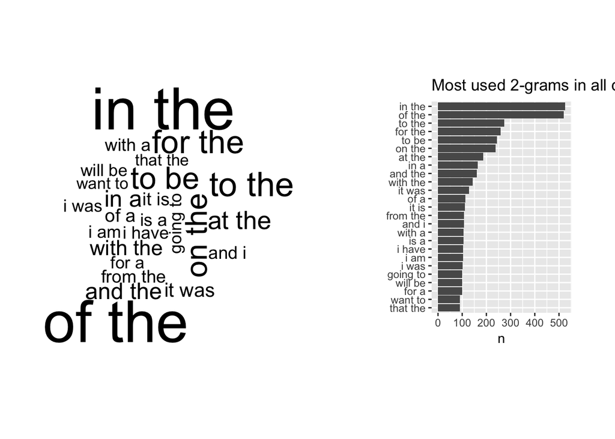

### 3.3. Trigram analysis

Finally, an analysis was performed on trigrams that are sequences of 3-words.

- the total number of trigrams is 131568
- the average length of the trigrams is 15.4
- The 10 most frequent trigrams are: [‘a lot of’ (55), ‘one of the’ (38), ‘thanks for the’ (29), ‘going to be’ (27), ‘i want to’ (23), ‘the end of’ (22), ‘a couple of’ (20), ‘i had a’ (19), ‘to be a’ (19), ‘out of the’ (18)]

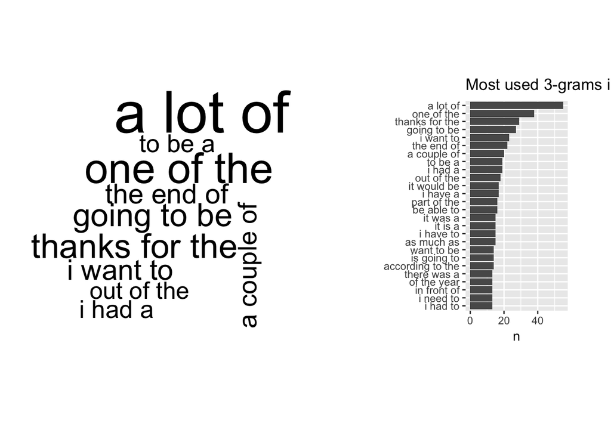

### 3.4. Word coverage

- total percentage of stop words: 43.1%
- total percentage of non-stop words: 56.9%
- total words to cover 50% of all word instances: 160 (0.1%)
- total words to cover 90% of all word instances: 6315 (4.8%)

Although we’re able to cover 90% of all words with a small percentage of unique words, in our particular problem, we need to take into account all other words that must be predicted.

### 3.6. Foreign language words

The package `textcat` can be used to detect the language of complete sentences in the corpora, but produces false positives. For example, running this package on a sample of 100 lines of text produces:

| lang | n |
| --- | --- |
| english | 78 |
| scots | 6 |
| afrikaans | 2 |
| frisian | 2 |
| middle_frisian | 2 |
| basque | 1 |
| breton | 1 |
| danish | 1 |
| estonian | 1 |
| german | 1 |
| indonesian | 1 |
| portuguese | 1 |
| romanian | 1 |
| slovak-ascii | 1 |
| slovak-windows1250 | 1 |

This process is computationally expensive: a simple empirical timing of `textcat` resulted in about 150/lines x second. Therefore processing the complete data-set would take about 0.0101852 hours.

Another procedure is to perform a spell check with `aspell` but it is expected to also be computationally expensive (not verified).

Finally a simple process could be to use `gsub` and a regular expression that matches words with non-English characters and removes them.

### 3.7. Oportunities to improve coverage:

This project is using a corpora of three predefined samples of news, blogs and twitter data. This corpora may not represent accurately the current English language usage among all users. There are other (open) data corpora available that can be used, and probably some smaller data-sets have been curated and provide better coverage. Also, depending on the usage of the final application, the model could be trained with more targeted data-sets.

## 4. Model proposal

During the initial research of NLP resources, and as recommended in the forum, I came across [[5]](http://www.decontextualize.com/teaching/dwwp/topics-n-grams-and-markov-chains/) that explains how to use python to state a similar problem using Markov chains. The procedure processes the text and extracts each n-gram and the words that follow. Then computes the probability of each word given the n-gram that preceded. Then this information can be structured into a Markov Chain to be used for predictions. This [YouTube resource](https://www.youtube.com/watch?v=dkUtavsPqNA&index=12&list=PL3CEFE83D76F8B515) also has interesting videos about NLP and in particular estimation of n-gram probabilities.

One problem that must be solved is how to represent this information in a compact way to be deployed on limited memory systems. A possible solution may be to use [word2vec](https://en.wikipedia.org/wiki/Word2vec), [GLoVe](http://nlp.stanford.edu/projects/glove/) and/or PCA to produce a more compact data structure. This will be researched more for next phases of the project.

## References

1. Text Mining in R, A Tidy Approach, Julia Silge and David Robinson, http://tidytextmining.com/
2. Tidy Data, Hadley Wickham, http://vita.had.co.nz/papers/tidy-data.pdf
3. CRAN Task View: Natural Language Processing, https://cran.r-project.org/web/views/NaturalLanguageProcessing.html
4. Crash Introduction to markovchain R package, Giorgio Alfredo Spedicato, Ph.D C.Stat ACAS, 2017-01-22, https://cran.r-project.org/web/packages/markovchain/vignettes/markovchainCrashIntro.pdf
5. Topics: N-Grams and Markov chains, Allison Parrish, http://www.decontextualize.com/teaching/dwwp/topics-n-grams-and-markov-chains/
6. NLP course https://www.youtube.com/watch?v=dkUtavsPqNA&index=12&list=PL3CEFE83D76F8B515